# Producing heat maps with **autoimage** and **ggplot2**

Joshua P. French

2021-03-15

## Introduction

The **autoimage** package makes it easy to plot a sequence of images with corresponding color scales, i.e., a sequence of heatmaps, with straightforward, native options for projection of geographical coordinates. The package makes it simple to add lines, points, and other features to the images, even when the coordinates are projected. The package allows for seamless creation of heat maps for data on regular or irregular grids, as well as data that is not on a grid.

The well-known **ggplot2** is a powerful and complete system for producing graphics in R. It can be used to produce many of the same heat maps as the **autoimage** package, particularly if additional packages are loaded.

In what follows, we look at how these packages can be used to produce various heat maps.

## Examples

In what follows, we make use of data from the North American Regional Climate Change Assessment Program (NARCCAP, http://www.narccap.ucar.edu/). Specifically, the data are the maximum daily surface air temperature (K) (abbreviated tasmax) for the five consecutive days of May 15, 2041 to May 19, 2041 simulated using the Canadian Regional Climate Model (Caya and Laprise, 1999) forced by the Community Climate System Model atmosphere-ocean general circular model (Collins et al., 2006). The data set contains `lon`, a 140 $\times$ 115 matrix of longitude coordinates, `lat`, a 140 $\times$ 115 matrix of latitude coordinates, and `tasmax`, a 140 $\times$ 115 $\times$ 5 array, where each element of the third dimension of the array corresponds to the `tasmax` measurements of the respective day.

### Basic Sequence of Heat Maps

We begin by creating a basic heat map using the two packages.

As a preliminary, we create a day vector related to the date of the temperatures.

```r
data(narccap)
dates <- c("May 15, 2041", "May 16, 2041", "May 17, 2041", "May 18, 2041", "May 19, 2041")
```

We produce a sequence of temperature heat maps using **autoimage**, labeling each image with the corresponding day.

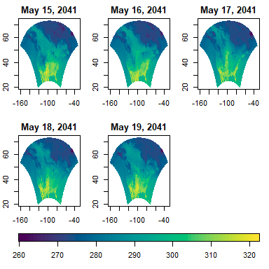

```r
autoimage(x = lon, y = lat, z = tasmax, main = dates)
```

To produce a similar plot using the **ggplot2** package, we must convert the data to a data frame, create a `ggplot` object, add the tile geometry, and facet by day. However, **ggplot2** currently requires the data are on a regular grid, which our data are not. If we attempt to create a heat map for a small subset of the original data using `ggplot2`, we obtain the following result. Because the original data are on an irregular grid, `ggplot2` cannot (currently) render a heat map for the data.

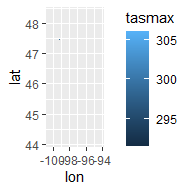

```r
df1 <- data.frame(lon = c(lon[65:75, 50:60]), lat = c(lat[65:75, 50:60]),
                  tasmax = c(tasmax[65:75, 50:60, 1]))
ggplot(df1, aes(x = lon, y = lat, z = tasmax, fill = tasmax)) + geom_tile()
```

Consequently, we load the `inarccap` data, which is the `narccap` data interplated onto a regular 140 $\times$ 115 grid using the `interp` function in the **akima** package.

```r
data(inarccap)
```

We now convert the interpolated data to a data frame suitable for **ggplot2**.

```r
igrid <- expand.grid(ilon, ilat)
df <- data.frame(lon = igrid[,1], lat = igrid[,2],
                 tasmax = c(itasmax),
                 day = rep(dates, each = 16100))
```

We are now able to create a sequence of heat maps using the **ggplot2** package. We will save the plotting structure as `gg_heatmaps` for future use.

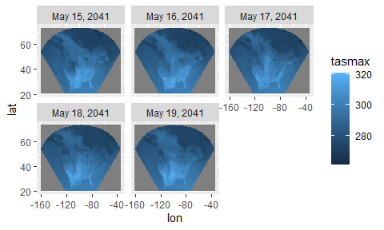

```r
gg_heatmaps <- ggplot() +
  geom_tile(aes(x = lon, y = lat, fill = tasmax), data = df) +
  facet_wrap(~ day)
print(gg_heatmaps)
```

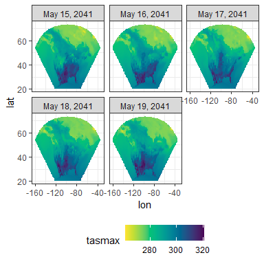

```r
library(colorspace)
gg_heatmaps <- gg_heatmaps +
  scale_fill_continuous_sequential("Viridis", na.value = "transparent") +
  theme_bw() + theme(legend.position = "bottom")
print(gg_heatmaps)
```

### Coordinate Projection

The locations of data used to create heat maps are often measured in longitude and latitude coordinates. In that case, it is often appropriate to apply a projection to the coordinates before plotting. Both **autoimage** and **ggplot2** provide native functionality for create heat maps for projected coordinates. This is done by specifying the `proj` and `parameters` arguments in the `autoimage` function for the **autoimage** package, or specifying the arguments of the `coord_map` function for **ggplot2**.

We demonstrate how to do this below by adding a specific Bonne projection to the previous examples.

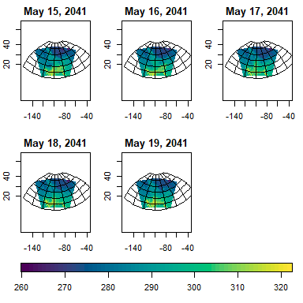

```r
autoimage(x = lon, y = lat, z = tasmax, main = dates,
          proj = "bonne", parameters = 45)
```

Rendering the heat maps with a projection takes noticeably longer when using the **ggplot2** package in comparison with the **autoimage** package, though exact timings depend on the user’s computer. For efficiency reasons, we do not execute the command below, though doing so would produce a heat map with projected coordinates using **ggplot2**.

```r
# gg_heatmaps +
#   coord_map(projection = "bonne", parameters = 45)
```

## Adding features

It is sometimes helpful to add geographical features of interest to a heat map, e.g., provincial borders, city locations, etc. This can be done using either package.

Both packages have several geographic maps built into the software. The **autoimage** package can automatically pull a map directly from the **maps** by specifying the appropriate name to the `map` argument. **ggplot2** has the same maps, which can be accessed using the `map_data` function. The map (specifically, the map boundaries) can then be added to the heat map using the `geom_path` function. If the map borders extend beyond the range of observed data, then the x and y limits must be provided to the `ggplot` object.

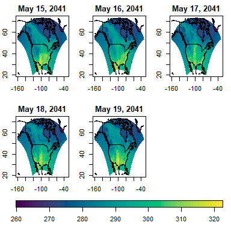

```r
autoimage(x = lon, y = lat, z = tasmax, main = dates, map = "world")
```

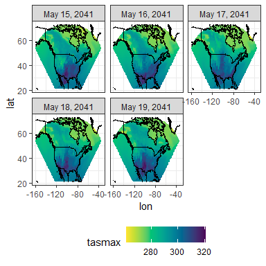

```r
world_df <- map_data("world")
gg_heatmaps +
  geom_path(aes(x = long, y = lat, group = group), data = world_df) +
  xlim(c(-160, -34)) + ylim(c(20.5, 73.1))
```

Consider arbitrary maps available in a standard shapefile. The `readOGR` and `spTransform` functions in the **rgdal** package can be used to read the shapefile and convert it to a `SpatialPolygon` object, which is used in the **sp** package. The `SpatialPolygons2map` function in the **maps** package can then be used to convert the object into a format used by the **maps** package. The **autoimage** package uses the same format for its maps and lines. These objects must be converted to a data frame before use with the **ggplot2** package.

Consider the `canada` data in the **autoimage** package, which contains the provincial and territorial boundaries for Canada. The data are already in the map format utilized by the **maps** and **autoimage** packages. We can convert this to a data frame compatible with **ggplot2** using the `tidy` function in the **broom** package.

```r
data(canada)
library(broom)
canada_df <- tidy(canada)
```

We now add the desired boundaries to the heat maps using each package.

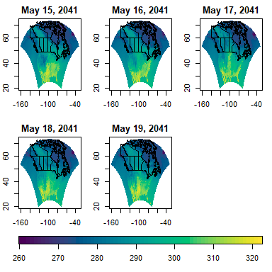

```r
autoimage(x = lon, y = lat, z = tasmax, main = dates, lines = canada)
```

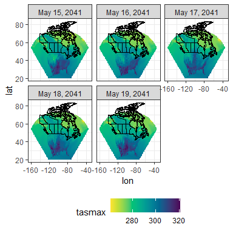

```r
gg_heatmaps +
  geom_path(aes(x = long, y = lat, group = group), data = canada_df)
```

Next, we consider adding points to existing heat maps. We plot a subset of the `us.cities` data found in the **maps** package. The **autoimage** is expecting the data frame to have components `x` and `y` specifying the `x` and `y` coordinates of the locations, so we create a data frame with this structure before plotting. The same data frame can be used by `ggplot2`.

```r
caps <- maps::us.cities[maps::us.cities$capital == 2, ]
caps <- caps[c(1, 3, 5, 22, 27, 42), ]
cap_df <- data.frame(x = caps$lon, y = caps$lat, labels = caps$country.etc)
```

We now create the desired heat maps.

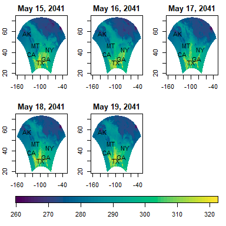

```r
autoimage(x = lon, y = lat, z = tasmax, main = dates, text = cap_df)
```

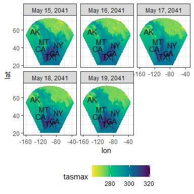

```r
gg_heatmaps +
  geom_text(aes(x = x, y = y, label = labels), data = cap_df)
```

## Individual heat maps

Sometimes there are reasons to construct heat maps with individual color scales, e.g., when the data are on different scales such as heat maps of predicted value versus standard error. This can be done natively in **autoimage**, but requires loading the **gridExtra** package for **ggplot2**. We demonstrate this functionality by creating heat maps with individual color scales for each day of the `narccap` data.

To create a sequence of images with individual color scales using the **autoimage** package, one simply specifies `common.legend = FALSE`.

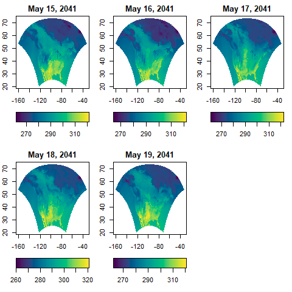

```r
autoimage(lon, lat, tasmax, common.legend = FALSE, main = dates)
```

To obtain a similar result using **ggplot2**, we first split the `df` data frame into a list of data frames, with each element of the list corresponding to the data for one of the days. We then create heat maps of the data for each day, then combine them into one plot using the `grid.arrange` function in the **gridExtra** package.

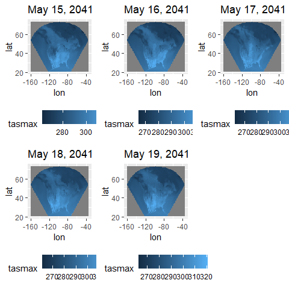

```r
df_days = split(df, f = df$day)
p1 <- ggplot(df_days[[1]], aes(x = lon, y = lat, fill = tasmax)) +
  geom_tile() + labs(title = dates[1]) +
  theme(legend.position = "bottom")
p2 <- ggplot(df_days[[2]], aes(x = lon, y = lat, fill = tasmax)) +
  geom_tile() + labs(title = dates[2]) +
  theme(legend.position = "bottom")
p3 <- ggplot(df_days[[3]], aes(x = lon, y = lat, fill = tasmax)) +
  geom_tile() + labs(title = dates[3]) +
  theme(legend.position = "bottom")
p4 <- ggplot(df_days[[4]], aes(x = lon, y = lat, fill = tasmax)) +
  geom_tile() + labs(title = dates[4]) +
  theme(legend.position = "bottom")
p5 <- ggplot(df_days[[5]], aes(x = lon, y = lat, fill = tasmax)) +
  geom_tile() + labs(title = dates[5]) +
  theme(legend.position = "bottom")
library(gridExtra)
grid.arrange(p1, p2, p3, p4, p5, nrow = 2, ncol = 3)
```

## Conclusion

In this vignette, we have briefly compared the approaches for producing heat maps using the **autoimage** and **ggplot2** packages. The packages have fairly similar capabilities for producing heat maps, though the style and steps to obtain the heat maps sometimes differ considerably. Additionally, the **ggplot2** package can be noticeably slower when producing heat maps for projected coordinates.

## References

Mearns, L.O., et al., 2007, updated 2012. The North American Regional Climate Change Assessment Program dataset, National Center for Atmospheric Research Earth System Grid data portal, Boulder, CO. Data downloaded 2016-08-12.

Mearns, L. O., W. J. Gutowski, R. Jones, L.-Y. Leung, S. McGinnis, A. M. B. Nunes, and Y. Qian: A regional climate change assessment program for North America. EOS, Vol. 90, No. 36, 8 September 2009, pp. 311-312.

D. Caya and R. Laprise. A semi-implicit semi-Lagrangian regional climate model: The Canadian RCM. Monthly Weather Review, 127(3):341–362, 1999.

M. Collins, B. B. Booth, G. R. Harris, J. M. Murphy, D. M. Sexton, and M. J. Webb. Towards quantifying uncertainty in transient climate change. Climate Dynamics, 27(2-3):127–147, 2006.